# 🛫_DTSA_5509_US_Airline_Passenger_Satisfaction

```python
# Start logging execution time
start_time = time.time()

# Generate summary statistics for the training dataset
# Explanation: The `describe()` method provides a summary of statistics for numerical columns by default.
# The `include=['category']` argument provides statistics for categorical columns, such as frequency and mode.

print("Training Set Summary Statistics:")
# Summary statistics for numerical columns
print("Numerical Columns Summary:")
print(df_train.describe())

# Summary statistics for categorical columns
print("\nCategorical Columns Summary:")
print(df_train.describe(include=['category']))

# Generate summary statistics for the testing dataset
print("\nTesting Set Summary Statistics:")
# Summary statistics for all columns (both numeric and categorical)
print("All Columns Summary:")
print(df_test.describe(include='all'))

# Summary statistics for categorical columns in the testing set
print("\nCategorical Columns Summary:")
print(df_test.describe(include=['category']))

# Log completion message and execution time
end_time = time.time()
execution_time = end_time - start_time
print(f"\nSummary statistics generation complete. Execution time: {execution_time:.2f} seconds.")
```

```
Training Set Summary Statistics:
Numerical Columns Summary:
                 Age  Flight Distance  Departure Delay in Minutes  \
count  103594.000000    103594.000000               103594.000000
mean       39.380466      1189.325202                   14.747939
std        15.113125       997.297235                   38.116737
min         7.000000        31.000000                    0.000000
25%        27.000000       414.000000                    0.000000
50%        40.000000       842.000000                    0.000000
75%        51.000000      1743.000000                   12.000000
max        85.000000      4983.000000                 1592.000000

       Arrival Delay in Minutes
count             103594.000000
mean                  15.178678
std                   38.698682
min                    0.000000
25%                    0.000000
50%                    0.000000
75%                   13.000000
max                 1584.000000

Categorical Columns Summary:
        Gender   Customer Type   Type of Travel     Class  \
count   103594          103594           103594    103594
unique       2               2                2         3
top     Female  Loyal Customer  Business travel  Business
freq     52576           84662            71465     49533

        Inflight wifi service  Departure/Arrival time convenient  \
count                  103594                             103594
unique                      6                                  6
top                         3                                  4
freq                    25789                              25474

        Ease of Online booking  Gate location  Food and drink  \
count                   103594         103594          103594
unique                       6              6               6
top                          3              3               4
freq                     24370          28489           24294
```

[output cut: 137 more lines]

```
freq               7682          7969                    7347

        On-board service  Leg room service  Baggage handling  Checkin service  \
count              25893             25893             25893            25893
unique                 6                 6                 5                5
top                    4                 4                 4                4
freq                7814              7075              9357             7254

        Inflight service  Cleanliness             satisfaction
count              25893        25893                    25893
unique                 6            6                        2
top                    4            4  neutral or dissatisfied
freq                9352         6771                    14528

Summary statistics generation complete. Execution time: 0.26 seconds.
```

**Observation** I use the `describe` method with default parameters to obtain summary statistics for quantitative features. This will provide the mean, standard deviation, minimum and maximum values, median, and quartile values for each attribute. For categorical features, it will display the total number of values, the number of unique values, the most frequent value, and its count. I will produce a couple of visualizations to explore data relationships.

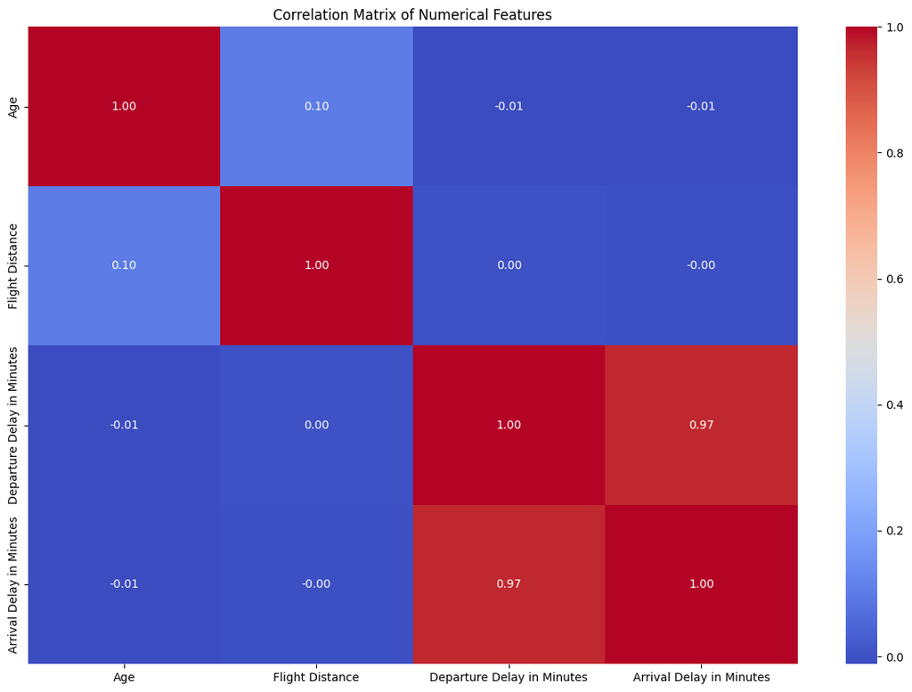

```
Correlation matrix plot generated. Execution time: 0.38 seconds.
```

```python
# Start logging execution time
start_time = time.time()

# Calculate the correlation matrix for numerical features in the training set
# Explanation: The `corr()` method computes the Pearson correlation coefficients for the numerical columns.
# This will show how strongly the features are related to each other (values closer to 1 or -1 indicate strong relationships).
correlation_matrix = df_train[numeric_columns].corr()

# Create the correlation plot using Seaborn's heatmap
# Explanation: A heatmap is a great way to visually display correlations, with color intensities representing the strength of correlation.
# The `annot=True` parameter adds the correlation values in each cell, `cmap='coolwarm'` specifies the color palette,
# and `fmt=".2f"` ensures the correlation values are displayed with two decimal places.
plt.figure(figsize=(15, 10))  # Set the size of the plot for better readability
sns.heatmap(correlation_matrix, annot=True, cmap='coolwarm', fmt=".2f", cbar=True)

# Title the plot for clarity
plt.title('Correlation Matrix of Numerical Features')

# Show the plot
plt.show()

# Log completion message and execution time
end_time = time.time()
execution_time = end_time - start_time
print(f"\nCorrelation matrix plot generated. Execution time: {execution_time:.2f} seconds.")
```

**Observation** Correlation analysis applies only to numerical features, so only four columns are considered. The analysis reveals a strong correlation between **Departure Delay in Minutes** and **Arrival Delay in Minutes**. This makes sense, as a delay at departure is likely to result in a similar delay at arrival, assuming no compensatory actions, such as speeding up during the flight, are taken. It may cause the collinearity issue in interpreting the model's coefficients due to redundancy in information they provide.

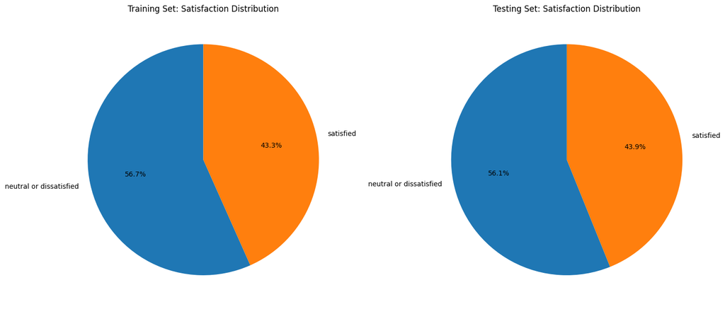

```
Pie charts generated. Execution time: 0.41 seconds.
```

```python
# Start logging execution time
start_time = time.time()

# Create subplots to display two pie charts side by side
# Explanation: The `figsize=(12, 6)` defines the size of the plot area,
# and `1, 2` means one row with two columns for pie charts.
fig, axes = plt.subplots(1, 2, figsize=(15, 10))

# Pie chart for satisfaction distribution in the training data
# Explanation: `value_counts()` counts occurrences of each category in the 'satisfaction' column,
# and `plot.pie()` generates a pie chart with the percentage of each category.
# `autopct='%1.1f%%'` formats the percentage labels to one decimal place,
# and `startangle=90` rotates the chart to start from the top.
df_train['satisfaction'].value_counts().plot.pie(autopct='%1.1f%%', ax=axes[0], startangle=90)
axes[0].set_title('Training Set: Satisfaction Distribution')  # Title for the first pie chart
axes[0].set_ylabel('')  # Remove the y-axis label for cleaner appearance

# Pie chart for satisfaction distribution in the testing data
# Same logic applies to the testing dataset.
df_test['satisfaction'].value_counts().plot.pie(autopct='%1.1f%%', ax=axes[1], startangle=90)
axes[1].set_title('Testing Set: Satisfaction Distribution')  # Title for the second pie chart
axes[1].set_ylabel('')  # Remove the y-axis label for cleaner appearance

# Adjust layout to prevent overlapping of titles and labels
plt.tight_layout()

# Display the plot
plt.show()

# Log completion message and execution time
end_time = time.time()
execution_time = end_time - start_time
print(f"\nPie charts generated. Execution time: {execution_time:.2f} seconds.")
```

**Observation** The pie chart shows that the distribution is fairly balanced.

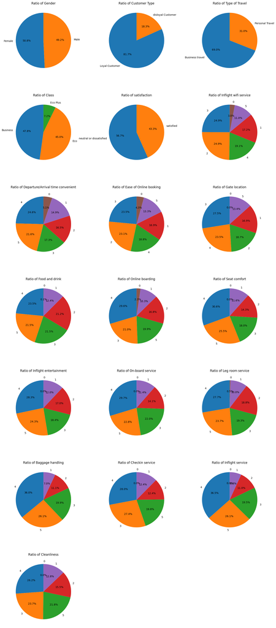

```
Pie charts for categorical features generated. Execution time: 1.99 seconds.
```

```python
# Start logging execution time
start_time = time.time()

# Create subplots for each categorical feature
# Explanation: We will dynamically calculate the number of rows and columns needed for the subplots.
# `num_features` is the total number of categorical features to plot.
# `num_cols` is set to 3, so the subplots will be arranged in 3 columns.
# `num_rows` is calculated based on the number of features and the number of columns.

num_features = len(categorical_columns)
num_cols = 3  # Number of columns in the subplot grid
num_rows = (num_features + num_cols - 1) // num_cols  # Calculate the number of rows needed

# Create the subplots with the calculated number of rows and columns
# Explanation: `figsize=(15, 5 * num_rows)` sets the figure size dynamically based on the number of rows.
fig, axes = plt.subplots(num_rows, num_cols, figsize=(15, 5 * num_rows))

# Flatten the axes array for easier iteration (from a 2D array to 1D)
axes = axes.flatten()

# Iterate over the categorical columns and create pie charts
for i, col in enumerate(categorical_columns):
    if i < num_features:  # Ensure we're not exceeding the number of categorical features
        # Generate the pie chart for each categorical feature
        # Explanation: `value_counts()` counts the occurrences of each category,
        # and `plot.pie()` generates the pie chart, formatted with percentage labels.
        df_train[col].value_counts().plot.pie(autopct='%1.1f%%', ax=axes[i], startangle=90)

        # Set title and remove y-label for each subplot
        axes[i].set_title(f'Ratio of {col}')
        axes[i].set_ylabel('')  # Remove y-label for cleaner presentation

# Remove any empty subplots if there are more subplots than features
for j in range(i + 1, len(axes)):
    fig.delaxes(axes[j])

# Adjust the layout to prevent overlapping of titles and labels
plt.tight_layout()

# Display the plot
plt.show()

# Log completion message and execution time
end_time = time.time()
execution_time = end_time - start_time
print(f"\nPie charts for categorical features generated. Execution time: {execution_time:.2f} seconds.")
```

**Observation**

- The number of male and female passengers in the sample is approximately equal.
- The majority of airline customers are repeat passengers.
- Most passengers traveled for business rather than personal reasons.
- Around half of the passengers were in business class.
- Over 60% of passengers rated the luggage transportation service 4 or 5 out of 5, indicating satisfaction.
- More than 50% of passengers rated seat comfort 4 or 5 out of 5, indicating a high level of comfort.

```python
# Start logging execution time
start_time = time.time()

# Separate features (X) and target (y) for the training set
# Explanation: The target variable 'satisfaction' is separated from the features (X)
# by dropping it from the dataframe and assigning the remaining columns to X_train.
# The `drop_first=True` parameter in `pd.get_dummies()` avoids multicollinearity by removing the first category.
# The `astype(int)` ensures that boolean columns are converted to integer values (1 for True, 0 for False).

X_train = df_train.drop('satisfaction', axis=1)  # Drop the target variable from features
X_train = pd.get_dummies(X_train, drop_first=True)  # Convert categorical features to dummy variables, drop the first category
X_train = X_train.astype(int)  # Convert any boolean values to integers (0/1)

print(f"The training dataset has {X_train.shape[0]} rows and {X_train.shape[1]} columns.")

# Target variable for training
y_train = df_train['satisfaction'].map({'neutral or dissatisfied': 0, 'satisfied': 1}).to_numpy()  # Extract the target variable ('satisfaction') for training

# Separate features (X) and target (y) for the testing set
# Repeat the same process as for the training set
X_test = df_test.drop('satisfaction', axis=1)  # Drop the target variable from features in the test set
X_test = pd.get_dummies(X_test, drop_first=True)  # Convert categorical features to dummy variables, drop the first category
X_test = X_test.astype(int)  # Convert boolean values to integers (0/1)

print(f"The test dataset has {X_test.shape[0]} rows and {X_test.shape[1]} columns.")  # Corrected message from "training" to "test" dataset

# Target variable for testing
y_test = df_test['satisfaction'].map({'neutral or dissatisfied': 0, 'satisfied': 1}).to_numpy()  # Extract the target variable ('satisfaction') for testing

# Get missing columns in the test set compared to the training set
missing_cols = set(X_train.columns) - set(X_test.columns)

# Add missing columns in the test set with default value equal to 0
for c in missing_cols:
    X_test[c] = 0
# Ensure the order of columns in the test set matches the training set
X_test = X_test[X_train.columns]

# Check again after ensuring the columns match
print(f"The training dataset has {X_train.shape[0]} rows and {X_train.shape[1]} columns.")
print(f"The test dataset has {X_test.shape[0]} rows and {X_test.shape[1]} columns.")

# Convert to NumPy arrays for model input
X_train = X_train.values
X_test = X_test.values

# Log completion message and execution time
end_time = time.time()
execution_time = end_time - start_time
print(f"\nFeature and target separation complete. Execution time: {execution_time:.2f} seconds.")
```

```
The training dataset has 103594 rows and 78 columns.
The test dataset has 25893 rows and 75 columns.
The training dataset has 103594 rows and 78 columns.
The test dataset has 25893 rows and 78 columns.

Feature and target separation complete. Execution time: 0.14 seconds.
```

```python
# Start logging execution time
start_time = time.time()

# Feature Scaling
# Explanation: Scaling ensures features have similar magnitude, which is important for algorithms like SVM and Logistic Regression.
# The StandardScaler standardizes features to have a mean of 0 and a standard deviation of 1 (z-score normalization).
scaler = StandardScaler()  # Initialize the scaler

# Fit the scaler to the training data and transform the features
X_train_scaled = scaler.fit_transform(X_train)
# Transform the test data using the same scaler (use training data parameters for consistency)
X_test_scaled = scaler.transform(X_test)

print(f"Feature scaling complete. X_train_scaled shape: {X_train_scaled.shape}, X_test_scaled shape: {X_test_scaled.shape}")

# Dimensionality Reduction using PCA
# Explanation: PCA reduces the dimensionality of data while retaining the specified percentage of variance (80% in this case).
# This helps reduce noise and improve computational efficiency for high-dimensional datasets.
pca = PCA(n_components=0.80)  # Retain 80% of the variance
X_train_pca = pca.fit_transform(X_train_scaled)  # Fit PCA on training data and transform
X_test_pca = pca.transform(X_test_scaled)       # Transform test data using the same PCA model

# Log PCA results
print(f"Original shape of X_train: {X_train_scaled.shape}")
print(f"Reduced shape of X_train after PCA: {X_train_pca.shape}")
print(f"Original shape of X_test: {X_test_scaled.shape}")
print(f"Reduced shape of X_test after PCA: {X_test_pca.shape}")

# Log completion message and execution time
end_time = time.time()
execution_time = end_time - start_time
print(f"\nFeature scaling and PCA complete. Execution time: {execution_time:.2f} seconds.")
```

```
Feature scaling complete. X_train_scaled shape: (103594, 78), X_test_scaled shape: (25893, 78)
Original shape of X_train: (103594, 78)
Reduced shape of X_train after PCA: (103594, 32)
Original shape of X_test: (25893, 78)
Reduced shape of X_test after PCA: (25893, 32)

Feature scaling and PCA complete. Execution time: 0.52 seconds.
```

# Model Building and Training

```
Training Logistic Regression...
Fitting 5 folds for each of 8 candidates, totalling 40 fits
```

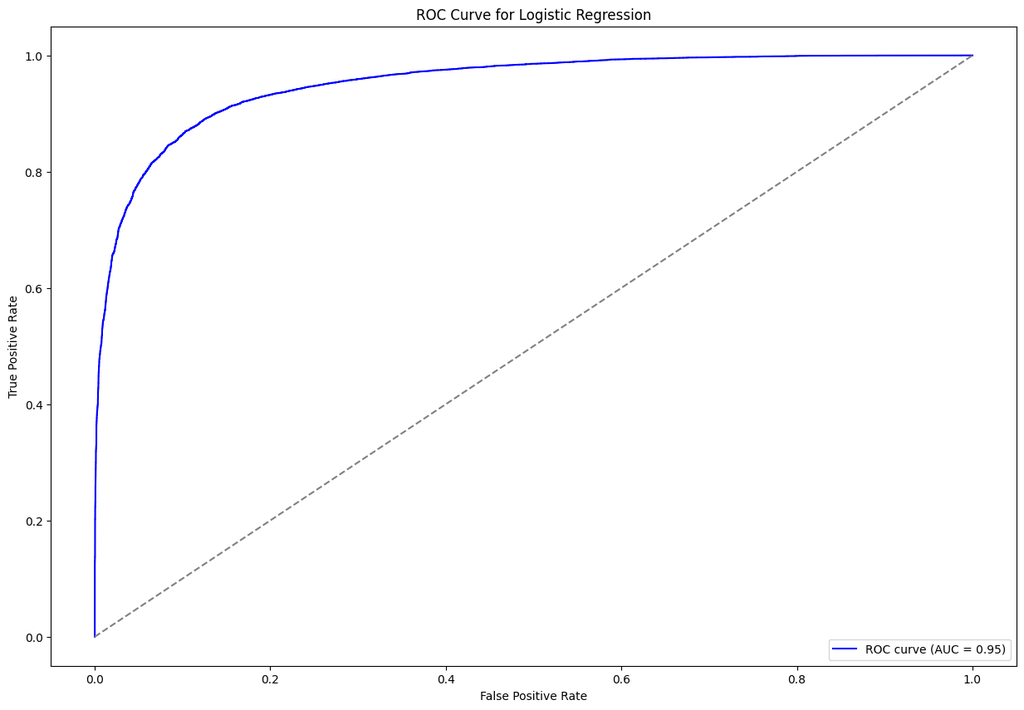

```
Classification Report for Logistic Regression:

              precision    recall  f1-score   support

           0       0.89      0.91      0.90     14528
           1       0.88      0.86      0.87     11365

    accuracy                           0.88     25893
   macro avg       0.88      0.88      0.88     25893
weighted avg       0.88      0.88      0.88     25893

Logistic Regression completed in 8.98 seconds.


Training Decision Tree...
Fitting 5 folds for each of 24 candidates, totalling 120 fits
```

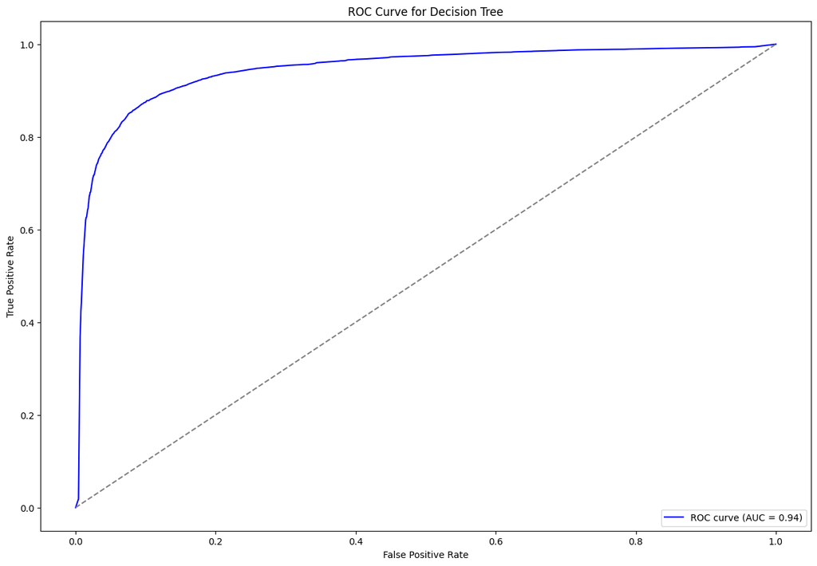

```
Classification Report for Decision Tree:

              precision    recall  f1-score   support

           0       0.90      0.91      0.90     14528
           1       0.88      0.87      0.87     11365

    accuracy                           0.89     25893
   macro avg       0.89      0.89      0.89     25893
weighted avg       0.89      0.89      0.89     25893

Decision Tree completed in 159.53 seconds.


Training Random Forest...
Fitting 5 folds for each of 12 candidates, totalling 60 fits
```

```
Training Random Forest exceeded the time limit and was terminated.
Random Forest completed in 600.00 seconds.


Training SVM...
Fitting 5 folds for each of 8 candidates, totalling 40 fits
```

```
Training SVM exceeded the time limit and was terminated.
SVM completed in 600.00 seconds.


Training kNN...
Fitting 5 folds for each of 6 candidates, totalling 30 fits
```

```
Training kNN exceeded the time limit and was terminated.
kNN completed in 600.00 seconds.


Training Extra Trees...
Fitting 5 folds for each of 12 candidates, totalling 60 fits
```

```
Training Extra Trees exceeded the time limit and was terminated.
Extra Trees completed in 600.00 seconds.


Training AdaBoost...
Fitting 5 folds for each of 6 candidates, totalling 30 fits
```

```
Training AdaBoost exceeded the time limit and was terminated.
AdaBoost completed in 600.00 seconds.


Model Performance Results:
                 Model                                    Best Parameters  \
0  Logistic Regression                       {'C': 0.1, 'solver': 'saga'}
1        Decision Tree  {'max_depth': 10, 'min_samples_leaf': 4, 'min_...
2        Random Forest                                                NaN
3                  SVM                                                NaN
4                  kNN                                                NaN
5          Extra Trees                                                NaN
6             AdaBoost                                                NaN

                                          Best Model  Accuracy  Precision  \
```

[output cut: 25 more lines]

```python
# Define models
models = {
    'Logistic Regression': LogisticRegression(),
    'Decision Tree': DecisionTreeClassifier(),
    'Random Forest': RandomForestClassifier(),
    'SVM': SVC(probability=True),
    # 'Ensemble (Voting Classifier)': VotingClassifier(estimators=[
    #     ('lr', LogisticRegression()),
    #     ('dt', DecisionTreeClassifier()),
    #     ('rf', RandomForestClassifier())
    # ], voting='hard'),
    'kNN': KNeighborsClassifier(),
    'Extra Trees': ExtraTreesClassifier(),
    'AdaBoost': AdaBoostClassifier()
}

# Hyperparameter grids
param_grids = {
    'Logistic Regression': {
        'C': [0.1, 1, 10, 100],
        'solver': ['liblinear', 'saga']
    },
    'Decision Tree': {
        'max_depth': [5, 10, 20, 40],
        'min_samples_split': [2, 5],
        'min_samples_leaf': [1, 2, 4]
    },
    'Random Forest': {
        'n_estimators': [100, 200, 400],
        'max_depth': [10, 20],
        'min_samples_split': [2, 5]
    },
    'SVM': {
        'C': [0.1, 1, 10, 100],
        'kernel': ['linear', 'rbf']
    },
    'kNN': {
        'n_neighbors': [3, 5, 7],
        'weights': ['uniform', 'distance']
    },
    'Extra Trees': {
        'n_estimators': [100, 200, 400],
        'max_depth': [10, 20],
        'min_samples_split': [2, 5]
    },
    'AdaBoost': {
        'n_estimators': [50, 100],
        'learning_rate': [0.01, 0.1, 1]
    }
    # 'Ensemble (Voting Classifier)': {}  # No hyperparameters for ensemble at the moment
}

# Logging results
results = []

# Function to train the model with GridSearchCV
def train_model_with_timeout(model_name, model, param_grid, X_train_pca, y_train, timeout):
    result = {"Model": model_name}
    try:
        best_model = [None]

        def train_task():
            if model_name != 'Ensemble (Voting Classifier)':
                grid_search = GridSearchCV(
                    estimator=model,
                    param_grid=param_grid,
                    cv=5,
                    scoring='accuracy',
                    verbose=1,
                    n_jobs=-1
                )
                grid_search.fit(X_train_pca, y_train)
                best_model[0] = grid_search.best_estimator_
                result['Best Parameters'] = grid_search.best_params_
            else:
                model.fit(X_train_pca, y_train)
                best_model[0] = model
                result['Best Parameters'] = 'N/A'

        # Start the training thread
        training_thread = threading.Thread(target=train_task)
        training_thread.start()
        training_thread.join(timeout=timeout)

        # Check if the training is completed
        if training_thread.is_alive():
            raise TimeoutError(f"Training {model_name} exceeded the time limit and was terminated.")
        else:
            result['Best Model'] = best_model[0]
    except TimeoutError as e:
        print(e)
        result['Error'] = str(e)
    except Exception as e:
        print(f"An error occurred while training {model_name}: {e}")
        result['Error'] = str(e)
    return result

# Train models with timeout
timeout_limit = 600  # 10 minutes in seconds
for model_name, model in tqdm.tqdm(models.items(), desc="Training models", total=len(models)):
    print(f"\nTraining {model_name}...")
    start_time = time.time()

    # Train the model with a timeout
    result = train_model_with_timeout(model_name, model, param_grids.get(model_name, {}), X_train_pca, y_train, timeout_limit)

    # If no error occurred, evaluate the model
    if 'Error' not in result:
        best_model = result['Best Model']
        try:
            y_pred = best_model.predict(X_test_pca)
            y_prob = best_model.predict_proba(X_test_pca)[:, 1]

            result.update({
                'Accuracy': accuracy_score(y_test, y_pred),
                'Precision': precision_score(y_test, y_pred, average='binary'),
                'Recall': recall_score(y_test, y_pred, average='binary'),
                'F1 Score': f1_score(y_test, y_pred, average='binary'),
                'AUC': roc_auc_score(y_test, y_prob)
            })

            # Display ROC curve
            fpr, tpr, _ = roc_curve(y_test, y_prob)
            plt.figure(figsize=(15, 10))
            plt.plot(fpr, tpr, color='blue', label=f'ROC curve (AUC = {result["AUC"]:.2f})')
            plt.plot([0, 1], [0, 1], color='gray', linestyle='--')
            plt.title(f'ROC Curve for {model_name}')
            plt.xlabel('False Positive Rate')
            plt.ylabel('True Positive Rate')
            plt.legend(loc='lower right')
            plt.show()

            # Print classification report
            print(f"\nClassification Report for {model_name}:\n")
            print(classification_report(y_test, y_pred))
        except NotFittedError as e:
            print(f"{model_name} was not properly fitted: {e}")

    results.append(result)
    end_time = time.time()
    print(f"{model_name} completed in {end_time - start_time:.2f} seconds.\n")

# Convert results to DataFrame for easy viewing
results_df = pd.DataFrame(results)

# Display the final results table
print("\nModel Performance Results:")
print(results_df)
```

```python
# Display the table containing the performance metrics (accuracy, precision, recall, etc.) for each of the machine learning models that were trained and evaluated
results_df
```

|  | Model | Best Parameters | Best Model | Accuracy | Precision | Recall | F1 Score | AUC | Error |
| --- | --- | --- | --- | --- | --- | --- | --- | --- | --- |
| 0 | Logistic Regression | {'C': 0.1, 'solver': 'saga'} | LogisticRegression(C=0.1, solver='saga') | 0.884023 | 0.876057 | 0.857017 | 0.866432 | 0.951799 | NaN |
| 1 | Decision Tree | {'max_depth': 10, 'min_samples_leaf': 4, 'min_... | DecisionTreeClassifier(max_depth=10, min_sampl... | 0.890279 | 0.881900 | 0.865992 | 0.873873 | 0.944879 | NaN |
| 2 | Random Forest | NaN | NaN | NaN | NaN | NaN | NaN | NaN | Training Random Forest exceeded the time limit... |
| 3 | SVM | NaN | NaN | NaN | NaN | NaN | NaN | NaN | Training SVM exceeded the time limit and was t... |
| 4 | kNN | NaN | NaN | NaN | NaN | NaN | NaN | NaN | Training kNN exceeded the time limit and was t... |
| 5 | Extra Trees | NaN | NaN | NaN | NaN | NaN | NaN | NaN | Training Extra Trees exceeded the time limit a... |
| 6 | AdaBoost | NaN | NaN | NaN | NaN | NaN | NaN | NaN | Training AdaBoost exceeded the time limit and ... |